# TensolFlow

## base

### constant

- 定数
- Sessionを起動して、runを実行しないとprintされない

```python
import tensorflow as tf
import numpy as np

# それぞれ定数を定義
a = tf.constant(1)
b = tf.constant(2, dtype=tf.float32, shape=[3,2])
c = tf.constant(np.arange(4), dtype=tf.float32, shape=[2,2])

print('a:', a)
print('b:', b)
print('c:', c)

sess = tf.Session()

print('a:', sess.run(a))
print('b:', sess.run(b))
print('c:', sess.run(c))
```

```
a: Tensor("Const:0", shape=(), dtype=int32)
b: Tensor("Const_1:0", shape=(3, 2), dtype=float32)
c: Tensor("Const_2:0", shape=(2, 2), dtype=float32)
a: 1
b: [[2. 2.]
 [2. 2.]
 [2. 2.]]
c: [[0. 1.]
 [2. 3.]]
```

### placeholder

- 箱を用意して、値をいれておくことができるもの
- feed_dict:配列の位置

```python
import tensorflow as tf
import numpy as np

# プレースホルダーを定義
x = tf.placeholder(dtype=tf.float32, shape=[None,3])

print('x:', x)

sess = tf.Session()

X = np.random.rand(2,3)
print('X:', X)

# プレースホルダにX[0]を入力
# shapeを(3,)から(1,3)にするためreshape
print('x:', sess.run(x, feed_dict={x:X[0].reshape(1,-1)}))
# プレースホルダにX[1]を入力
print('x:', sess.run(x, feed_dict={x:X[1].reshape(1,-1)}))
```

```
x: Tensor("Placeholder:0", shape=(?, 3), dtype=float32)
X: [[0.93333918 0.6450491  0.42637424]
 [0.25482548 0.12803203 0.28462358]]
x: [[0.9333392  0.6450491  0.42637423]]
x: [[0.25482547 0.12803203 0.28462356]]
```

### variables

```python
# 定数を定義
a = tf.constant(10)
print('a:', a)
# 変数を定義
x = tf.Variable(1)
print('x:', x)

calc_op = x * a

# xの値を更新
update_x = tf.assign(x, calc_op)  # ←　値の代入

sess = tf.Session()

# 変数の初期化
init = tf.global_variables_initializer() # 変数の初期化
sess.run(init)

print(sess.run(x))

sess.run(update_x)
print(sess.run(x))

sess.run(update_x)
print(sess.run(x))
```

```
a: Tensor("Const_4:0", shape=(), dtype=int32)
x: <tf.Variable 'Variable_1:0' shape=() dtype=int32_ref>
1
10
100
```

```python
sess.run(update_x)
print(sess.run(x))

sess.run(init)
print(sess.run(x))
print(sess.run(update_x))
```

```
1000
1
10
```

## 線形回帰

### [try]

- noiseの値を変更しよう  
  （考察)noiseが大きいと収束しづらくなり、時間がかかる
- dの数値を変更しよう  
  （考察) dの値は、(収束、計算回数に)影響与えない

```
WARNING:tensorflow:From C:\ProgramData\Anaconda3\lib\site-packages\tensorflow\python\ops\math_ops.py:3066: to_int32 (from tensorflow.python.ops.math_ops) is deprecated and will be removed in a future version.
Instructions for updating:
Use tf.cast instead.
Generation: 10. 誤差 = 1.5800875
Generation: 20. 誤差 = 1.3185792
Generation: 30. 誤差 = 1.2688134
Generation: 40. 誤差 = 1.2322992
Generation: 50. 誤差 = 1.2051278
Generation: 60. 誤差 = 1.1849074
Generation: 70. 誤差 = 1.1698596
Generation: 80. 誤差 = 1.1586614
Generation: 90. 誤差 = 1.150328
Generation: 100. 誤差 = 1.1441264
Generation: 110. 誤差 = 1.1395111
Generation: 120. 誤差 = 1.1360766
Generation: 130. 誤差 = 1.1335206
Generation: 140. 誤差 = 1.1316186
Generation: 150. 誤差 = 1.130203
Generation: 160. 誤差 = 1.1291497
Generation: 170. 誤差 = 1.1283658
Generation: 180. 誤差 = 1.1277823
Generation: 190. 誤差 = 1.1273483
Generation: 200. 誤差 = 1.1270251
Generation: 210. 誤差 = 1.1267848
Generation: 220. 誤差 = 1.1266059
Generation: 230. 誤差 = 1.1264727
Generation: 240. 誤差 = 1.1263736
Generation: 250. 誤差 = 1.1262999
Generation: 260. 誤差 = 1.126245
Generation: 270. 誤差 = 1.1262041
Generation: 280. 誤差 = 1.1261737
Generation: 290. 誤差 = 1.1261512
Generation: 300. 誤差 = 1.1261343
[4.881636]
[5.029943]
```

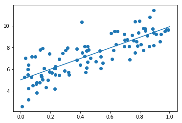

```python
import numpy as np
import tensorflow as tf
import matplotlib.pyplot as plt
%matplotlib inline

iters_num = 300           # 何回学習を行うか？
plot_interval = 10        # 何学習ごとに誤差を確認するか？

# データを生成
n = 100
x = np.random.rand(n)
d = 3 * x + 5             # 教師データ default
d = 5 * x + 5             # 教師データ

# ノイズを加える
noise = 0.3 # default
noise = 1
d = d + noise * np.random.randn(n) # 教師データにノイズを加える

# 入力値
xt = tf.placeholder(tf.float32)
dt = tf.placeholder(tf.float32)

# 最適化の対象の変数を初期化
W = tf.Variable(tf.zeros([1]))
b = tf.Variable(tf.zeros([1]))

y = W * xt + b

# 誤差関数 平均2乗誤差
loss = tf.reduce_mean(tf.square(y - dt))           # 平均2乗誤差
optimizer = tf.train.GradientDescentOptimizer(0.1)
train = optimizer.minimize(loss)

# 初期化
init = tf.global_variables_initializer()
sess = tf.Session()
sess.run(init)

# 作成したデータをトレーニングデータとして準備
x_train = x.reshape(-1,1)  # x:100個のランダムデータ
d_train = d.reshape(-1,1)  #  3x+2 にノイズを加えた100個のデータ

# トレーニング
for i in range(iters_num):
    sess.run(train, feed_dict={xt:x_train,dt:d_train})
    if (i+1) % plot_interval == 0:
        loss_val = sess.run(loss, feed_dict={xt:x_train,dt:d_train})
        W_val = sess.run(W)
        b_val = sess.run(b)
        print('Generation: ' + str(i+1) + '. 誤差 = ' + str(loss_val))

print(W_val)
print(b_val)

#  予測関数
def predict(x):
    return W_val * x + b_val

fig = plt.figure()
subplot = fig.add_subplot(1, 1, 1)
plt.scatter(x, d)
linex = np.linspace(0, 1, 2)
liney = predict(linex)
subplot.plot(linex,liney)
plt.show()
```

## 非線形回帰

### [try]

- noiseの値を変更しよう
- dの数値を変更しよう  
  （考察) noiseの値が小さければ、tensorflowの非線形回帰で予測可能

```
Generation: 100. 誤差 = 406.8009
Generation: 200. 誤差 = 388.73746
Generation: 300. 誤差 = 371.3274
Generation: 400. 誤差 = 354.5504
Generation: 500. 誤差 = 338.38733
Generation: 600. 誤差 = 322.81967
Generation: 700. 誤差 = 307.82968
Generation: 800. 誤差 = 293.40033
Generation: 900. 誤差 = 279.51535
Generation: 1000. 誤差 = 266.15894
Generation: 1100. 誤差 = 253.31606
Generation: 1200. 誤差 = 240.97215
Generation: 1300. 誤差 = 229.11319
Generation: 1400. 誤差 = 217.72572
Generation: 1500. 誤差 = 206.79674
Generation: 1600. 誤差 = 196.31366
Generation: 1700. 誤差 = 186.2643
Generation: 1800. 誤差 = 176.63692
Generation: 1900. 誤差 = 167.42006
Generation: 2000. 誤差 = 158.60274
Generation: 2100. 誤差 = 150.17406
Generation: 2200. 誤差 = 142.12355
Generation: 2300. 誤差 = 134.44098
Generation: 2400. 誤差 = 127.11635
Generation: 2500. 誤差 = 120.13982
Generation: 2600. 誤差 = 113.501816
Generation: 2700. 誤差 = 107.19283
Generation: 2800. 誤差 = 101.20357
Generation: 2900. 誤差 = 95.52484
Generation: 3000. 誤差 = 90.147575
Generation: 3100. 誤差 = 85.062805
Generation: 3200. 誤差 = 80.26162
Generation: 3300. 誤差 = 75.73517
Generation: 3400. 誤差 = 71.47471
Generation: 3500. 誤差 = 67.4715
Generation: 3600. 誤差 = 63.716854
Generation: 3700. 誤差 = 60.20213
Generation: 3800. 誤差 = 56.918667
Generation: 3900. 誤差 = 53.857864
Generation: 4000. 誤差 = 51.011105
```

[output cut: 49 more lines]

```
Generation: 9000. 誤差 = 24.24156
Generation: 9100. 誤差 = 24.227903
Generation: 9200. 誤差 = 24.214218
Generation: 9300. 誤差 = 24.200485
Generation: 9400. 誤差 = 24.186691
Generation: 9500. 誤差 = 24.172844
Generation: 9600. 誤差 = 24.158937
Generation: 9700. 誤差 = 24.145
Generation: 9800. 誤差 = 24.131035
Generation: 9900. 誤差 = 24.11708
Generation: 10000. 誤差 = 24.103151
[[-4.727512 ]
 [ 4.0385575]
 [-3.687875 ]
 [ 1.72962  ]]
```

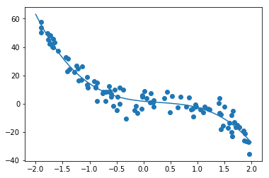

```python
import numpy as np
import tensorflow as tf
import matplotlib.pyplot as plt

iters_num = 10000
plot_interval = 100

# データを生成
n=100
x = np.random.rand(n).astype(np.float32) * 4 - 2
# d =  - 0.4 * x ** 3 + 1.6 * x ** 2 - 2.8 * x + 1
d =  - 5 * x ** 3 + 4 * x ** 2 - 2.8 * x + 1

#  ノイズを加える
noise = 0.05  # defalut
noise = 5
d = d + noise * np.random.randn(n)

# モデル
# bを使っていないことに注意.
xt = tf.placeholder(tf.float32, [None, 4])
dt = tf.placeholder(tf.float32, [None, 1])
W = tf.Variable(tf.random_normal([4, 1], stddev=0.01))
y = tf.matmul(xt,W)

# 誤差関数 平均２乗誤差
loss = tf.reduce_mean(tf.square(y - dt))
optimizer = tf.train.AdamOptimizer(0.001)
train = optimizer.minimize(loss)

# 初期化
init = tf.global_variables_initializer()
sess = tf.Session()
sess.run(init)

# 作成したデータをトレーニングデータとして準備
d_train = d.reshape(-1,1)
x_train = np.zeros([n, 4])
for i in range(n):
    for j in range(4):
        x_train[i, j] = x[i]**j

#  トレーニング
for i in range(iters_num):
    if (i+1) % plot_interval == 0:
        loss_val = sess.run(loss, feed_dict={xt:x_train, dt:d_train})
        W_val = sess.run(W)
        print('Generation: ' + str(i+1) + '. 誤差 = ' + str(loss_val))
    sess.run(train, feed_dict={xt:x_train,dt:d_train})

print(W_val[::-1])

# 予測関数
def predict(x):
    result = 0.
    for i in range(0,4):
        result += W_val[i,0] * x ** i
    return result

fig = plt.figure()
subplot = fig.add_subplot(1,1,1)
plt.scatter(x ,d)
linex = np.linspace(-2,2,100)
liney = predict(linex)
subplot.plot(linex,liney)
plt.show()
```

## [try]

- 次の式をモデルとして回帰を行おう $$ y=30x^{2} +0.5x+0.2 $$
- 誤差が収束するようiters_numやlearning_rateを調整しよう  
  （考察) iters_num=10000, learning_rate=0.1でも十分問題ないと推測される。

```
Generation: 1000. 誤差 = 8.485798
Generation: 2000. 誤差 = 0.0030774272
Generation: 3000. 誤差 = 4.8657203e-09
Generation: 4000. 誤差 = 1.2469143e-09
Generation: 5000. 誤差 = 4.575455e-10
Generation: 6000. 誤差 = 1.6027829e-10
Generation: 7000. 誤差 = 7.4775075e-11
Generation: 8000. 誤差 = 2.0091581e-11
Generation: 9000. 誤差 = 1.2541066e-11
Generation: 10000. 誤差 = 1.4775842e-11
[[29.999998 ]
 [ 0.4999998]
 [ 0.200002 ]]
```

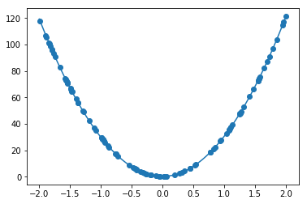

```python
import numpy as np
import tensorflow as tf
import matplotlib.pyplot as plt

iters_num = 30000 # default
iters_num = 10000
plot_interval = 1000

input_layer_size = 3
output_layer_size =1

# データを生成
n=100
x = np.random.rand(n).astype(np.float32) * 4 - 2  # -2から2までの数値を発生
d =  30 * x ** 2 + 0.5 * x + 0.2                  # 変更

#  ノイズを加える
# noise = 0.05
# d = d + noise * np.random.randn(n)

# モデル
# bを使っていないことに注意.
xt = tf.placeholder(tf.float32, [None, input_layer_size])  # 4→3
dt = tf.placeholder(tf.float32, [None, output_layer_size])
W = tf.Variable(tf.random_normal([input_layer_size, 1], stddev=0.01)) # 4→3
y = tf.matmul(xt,W)

# 誤差関数 平均２乗誤差
loss = tf.reduce_mean(tf.square(y - dt))
# optimizer = tf.train.AdamOptimizer(0.01) # default
optimizer = tf.train.AdamOptimizer(0.1) #
train = optimizer.minimize(loss)

# 初期化
init = tf.global_variables_initializer()
sess = tf.Session()
sess.run(init)

# 作成したデータをトレーニングデータとして準備
d_train = d.reshape(-1,output_layer_size)
x_train = np.zeros([n, input_layer_size])  # 4→3
for i in range(n):
    for j in range(input_layer_size):  # 4→3
        x_train[i, j] = x[i]**j

#  トレーニング
for i in range(iters_num):
    if (i+1) % plot_interval == 0:
        loss_val = sess.run(loss, feed_dict={xt:x_train, dt:d_train})
        W_val = sess.run(W)
        print('Generation: ' + str(i+1) + '. 誤差 = ' + str(loss_val))
    sess.run(train, feed_dict={xt:x_train,dt:d_train})

print(W_val[::-1])

# 予測関数
def predict(x):
    result = 0.
    for i in range(0,input_layer_size): # 4→3
        result += W_val[i,0] * x ** i
    return result

fig = plt.figure()
subplot = fig.add_subplot(1,1,1)
plt.scatter(x ,d)
linex = np.linspace(-2,2,100)
liney = predict(linex)
subplot.plot(linex,liney)
plt.show()
```

## 分類1層 (mnist)

## - x：入力値, d：教師データ, W：重み, b：バイアス をそれぞれ定義しよう

[output not shown]

[output cut: 167 more lines]

```
Generation: 93. 正解率 = 0.8634
[ True  True  True ...  True  True  True]
Generation: 94. 正解率 = 0.8658
[ True  True  True ...  True False  True]
Generation: 95. 正解率 = 0.8617
[ True  True  True ...  True False  True]
Generation: 96. 正解率 = 0.8672
[ True  True  True ...  True False  True]
Generation: 97. 正解率 = 0.8656
[ True  True  True ...  True False  True]
Generation: 98. 正解率 = 0.8662
[ True  True  True ...  True  True  True]
Generation: 99. 正解率 = 0.8693
[ True  True  True ...  True  True  True]
Generation: 100. 正解率 = 0.8677
```

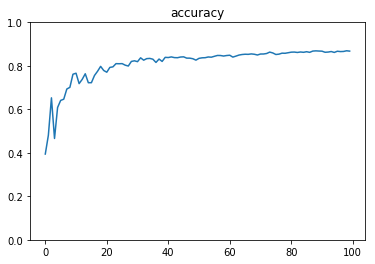

```python
import tensorflow as tf
import matplotlib.pyplot as plt
from tensorflow.examples.tutorials.mnist import input_data
mnist = input_data.read_data_sets("MNIST_data/", one_hot=True)

iters_num = 100
batch_size = 100
plot_interval = 1

# -------------- ここを補填 ------------------------
x = tf.placeholder(tf.float32, [None, 784])
d = tf.placeholder(tf.float32, [None, 10])
W = tf.Variable(tf.random_normal([784, 10], stddev=0.01))
b = tf.Variable(tf.zeros([10]))
# ------------------------------------------------------

y = tf.nn.softmax(tf.matmul(x, W) + b)

# 交差エントロピー
cross_entropy = -tf.reduce_sum(d * tf.log(y), reduction_indices=[1])
loss = tf.reduce_mean(cross_entropy)
train = tf.train.GradientDescentOptimizer(0.1).minimize(loss)

# 正誤を保存
correct = tf.equal(tf.argmax(y, 1), tf.argmax(d, 1))
# 正解率
accuracy = tf.reduce_mean(tf.cast(correct, tf.float32))

init = tf.global_variables_initializer()
sess = tf.Session()
sess.run(init)

accuracies = []
for i in range(iters_num):
    x_batch, d_batch = mnist.train.next_batch(batch_size)
    sess.run(train, feed_dict={x: x_batch, d: d_batch})
    if (i+1) % plot_interval == 0:
        print(sess.run(correct, feed_dict={x: mnist.test.images, d: mnist.test.labels}))
        accuracy_val = sess.run(accuracy, feed_dict={x: mnist.test.images, d: mnist.test.labels})
        accuracies.append(accuracy_val)
        print('Generation: ' + str(i+1) + '. 正解率 = ' + str(accuracy_val))


lists = range(0, iters_num, plot_interval)
plt.plot(lists, accuracies)
plt.title("accuracy")
plt.ylim(0, 1.0)
plt.show()
```

```python
d_batch[0]
```

```
array([0., 0., 0., 0., 0., 0., 0., 0., 0., 1.])
```

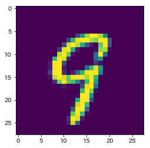

```python
plt.imshow(x_batch[0].reshape(28,28))
```

## 分類3層 (mnist)

## [try]

- 隠れ層のサイズを変更してみよう
- optimizerを変更しよう

tf.train.GradientDescentOptimizer

```
__init__(
    learning_rate,
    use_locking=False,
    name='GradientDescent'
)
```

tf.train.MomentumOptimizer

```
__init__(
    learning_rate,
    momentum,
    use_locking=False,
    name='Momentum',
    use_nesterov=False
)
```

tf.train.AdagradOptimizer

```
__init__(
    learning_rate,
    initial_accumulator_value=0.1,
    use_locking=False,
    name='Adagrad'
)
```

tf.train.RMSPropOptimizer

```
__init__(
    learning_rate,
    decay=0.9,
    momentum=0.0,
    epsilon=1e-10,
    use_locking=False,
    centered=False,
    name='RMSProp'
)
```

tf.train.AdamOptimizer

```
__init__(
    learning_rate=0.001,
    beta1=0.9,
    beta2=0.999,
    epsilon=1e-08,
    use_locking=False,
    name='Adam'
)
```

```
Extracting MNIST_data/train-images-idx3-ubyte.gz
Extracting MNIST_data/train-labels-idx1-ubyte.gz
Extracting MNIST_data/t10k-images-idx3-ubyte.gz
Extracting MNIST_data/t10k-labels-idx1-ubyte.gz
Generation: 100. 正解率 = 0.1948
Generation: 200. 正解率 = 0.2833
Generation: 300. 正解率 = 0.4027
Generation: 400. 正解率 = 0.5185
Generation: 500. 正解率 = 0.6311
Generation: 600. 正解率 = 0.6731
Generation: 700. 正解率 = 0.7143
Generation: 800. 正解率 = 0.7551
Generation: 900. 正解率 = 0.7719
Generation: 1000. 正解率 = 0.8004
Generation: 1100. 正解率 = 0.8174
Generation: 1200. 正解率 = 0.8247
Generation: 1300. 正解率 = 0.8382
Generation: 1400. 正解率 = 0.8448
Generation: 1500. 正解率 = 0.8536
Generation: 1600. 正解率 = 0.8568
Generation: 1700. 正解率 = 0.8635
Generation: 1800. 正解率 = 0.8686
Generation: 1900. 正解率 = 0.8728
Generation: 2000. 正解率 = 0.8776
Generation: 2100. 正解率 = 0.8811
Generation: 2200. 正解率 = 0.8857
Generation: 2300. 正解率 = 0.8878
Generation: 2400. 正解率 = 0.8889
Generation: 2500. 正解率 = 0.8922
Generation: 2600. 正解率 = 0.8951
Generation: 2700. 正解率 = 0.8972
Generation: 2800. 正解率 = 0.8979
Generation: 2900. 正解率 = 0.9
Generation: 3000. 正解率 = 0.9012
```

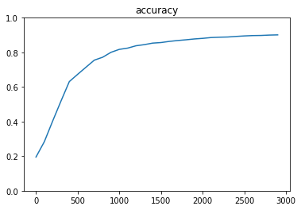

```python
import tensorflow as tf
import numpy as np
from tensorflow.examples.tutorials.mnist import input_data
import matplotlib.pyplot as plt

mnist = input_data.read_data_sets("MNIST_data/", one_hot=True)

iters_num = 3000
batch_size = 100
plot_interval = 100

hidden_layer_size_1 = 600
hidden_layer_size_2 = 300

dropout_rate = 0.5

x = tf.placeholder(tf.float32, [None, 784])
d = tf.placeholder(tf.float32, [None, 10])
W1 = tf.Variable(tf.random_normal([784, hidden_layer_size_1], stddev=0.01))
W2 = tf.Variable(tf.random_normal([hidden_layer_size_1, hidden_layer_size_2], stddev=0.01))
W3 = tf.Variable(tf.random_normal([hidden_layer_size_2, 10], stddev=0.01))

b1 = tf.Variable(tf.zeros([hidden_layer_size_1]))
b2 = tf.Variable(tf.zeros([hidden_layer_size_2]))
b3 = tf.Variable(tf.zeros([10]))

z1 = tf.sigmoid(tf.matmul(x, W1) + b1)
z2 = tf.sigmoid(tf.matmul(z1, W2) + b2)

keep_prob = tf.placeholder(tf.float32)
drop = tf.nn.dropout(z2, keep_prob)

y = tf.nn.softmax(tf.matmul(drop, W3) + b3)
loss = tf.reduce_mean(-tf.reduce_sum(d * tf.log(y), reduction_indices=[1]))


# optimizer = tf.train.GradientDescentOptimizer(0.5)
# optimizer = tf.train.MomentumOptimizer(0.1, 0.9)
# optimizer = tf.train.AdagradOptimizer(0.1)
# optimizer = tf.train.RMSPropOptimizer(0.001)
optimizer = tf.train.AdamOptimizer(1e-4)

train = optimizer.minimize(loss)
correct = tf.equal(tf.argmax(y, 1), tf.argmax(d, 1))
accuracy = tf.reduce_mean(tf.cast(correct, tf.float32))

init = tf.global_variables_initializer()
sess = tf.Session()
sess.run(init)

accuracies = []
for i in range(iters_num):
    x_batch, d_batch = mnist.train.next_batch(batch_size)
    sess.run(train, feed_dict={x:x_batch, d:d_batch, keep_prob:(1 - dropout_rate)})
    if (i+1) % plot_interval == 0:
        accuracy_val = sess.run(accuracy, feed_dict={x:mnist.test.images, d:mnist.test.labels, keep_prob:1.0})
        accuracies.append(accuracy_val)
        print('Generation: ' + str(i+1) + '. 正解率 = ' + str(accuracy_val))

lists = range(0, iters_num, plot_interval)
plt.plot(lists, accuracies)
plt.title("accuracy")
plt.ylim(0, 1.0)
plt.show()
```

tf.train.GradientDescentOptimizer(0.5) 正解率 = 0.9133  
tf.train.MomentumOptimizer(0.1, 0.9) 正解率 = 0.945  
tf.train.AdagradOptimizer(0.1) 正解率 = 0.8939  
tf.train.RMSPropOptimizer(0.001) 正解率 = 0.968  
tf.train.AdamOptimizer(1e-4) 正解率 = 0.9012

## 分類CNN (mnist)

conv - relu - pool - conv - relu - pool -  
affin - relu - dropout - affin - softmax

## - ドロップアウト率を0に変更しよう

```
Extracting MNIST_data/train-images-idx3-ubyte.gz
Extracting MNIST_data/train-labels-idx1-ubyte.gz
Extracting MNIST_data/t10k-images-idx3-ubyte.gz
Extracting MNIST_data/t10k-labels-idx1-ubyte.gz
Generation: 10. 正解率 = 0.22
Generation: 20. 正解率 = 0.45
Generation: 30. 正解率 = 0.72
Generation: 40. 正解率 = 0.77
Generation: 50. 正解率 = 0.79
Generation: 60. 正解率 = 0.85
Generation: 70. 正解率 = 0.8
Generation: 80. 正解率 = 0.84
Generation: 90. 正解率 = 0.84
Generation: 100. 正解率 = 0.84
Generation: 110. 正解率 = 0.91
Generation: 120. 正解率 = 0.89
Generation: 130. 正解率 = 0.9
Generation: 140. 正解率 = 0.88
Generation: 150. 正解率 = 0.88
Generation: 160. 正解率 = 0.89
Generation: 170. 正解率 = 0.9
Generation: 180. 正解率 = 0.89
Generation: 190. 正解率 = 0.89
Generation: 200. 正解率 = 0.95
Generation: 210. 正解率 = 0.99
Generation: 220. 正解率 = 0.91
Generation: 230. 正解率 = 0.93
Generation: 240. 正解率 = 0.91
Generation: 250. 正解率 = 0.96
Generation: 260. 正解率 = 0.97
Generation: 270. 正解率 = 0.91
Generation: 280. 正解率 = 0.91
Generation: 290. 正解率 = 0.93
Generation: 300. 正解率 = 0.93
```

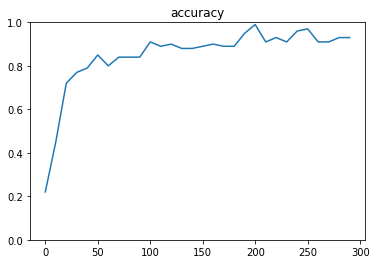

```python
import tensorflow as tf
from tensorflow.examples.tutorials.mnist import input_data
mnist = input_data.read_data_sets("MNIST_data/", one_hot=True)
import matplotlib.pyplot as plt

iters_num = 300
batch_size = 100
plot_interval = 10

# dropout_rate = 0.5 # defalut
dropout_rate = 0

# placeholder
x = tf.placeholder(tf.float32, shape=[None, 784])
d = tf.placeholder(tf.float32, shape=[None, 10])

# 画像を784の一次元から28x28の二次元に変換する
# 画像を28x28にreshape
x_image = tf.reshape(x, [-1,28,28,1])

# 第一層のweightsとbiasのvariable
W_conv1 = tf.Variable(tf.truncated_normal([5, 5, 1, 32], stddev=0.1))
b_conv1 = tf.Variable(tf.constant(0.1, shape=[32]))

# 第一層のconvolutionalとpool
# strides[0] = strides[3] = 1固定
h_conv1 = tf.nn.relu(tf.nn.conv2d(x_image, W_conv1, strides=[1, 1, 1, 1], padding='SAME') + b_conv1)
# プーリングサイズ n*n にしたい場合 ksize=[1, n, n, 1]
h_pool1 = tf.nn.max_pool(h_conv1, ksize=[1, 2, 2, 1], strides=[1, 2, 2, 1], padding='SAME')

# 第二層
W_conv2 = tf.Variable(tf.truncated_normal([5, 5, 32, 64], stddev=0.1))
b_conv2 = tf.Variable(tf.constant(0.1, shape=[64]))
h_conv2 = tf.nn.relu(tf.nn.conv2d(h_pool1, W_conv2, strides=[1, 1, 1, 1], padding='SAME') + b_conv2)
h_pool2 = tf.nn.max_pool(h_conv2, ksize=[1, 2, 2, 1], strides=[1, 2, 2, 1], padding='SAME')

# 第一層と第二層でreduceされてできた特徴に対してrelu
W_fc1 = tf.Variable(tf.truncated_normal([7 * 7 * 64, 1024], stddev=0.1))
b_fc1 = tf.Variable(tf.constant(0.1, shape=[1024]))
h_pool2_flat = tf.reshape(h_pool2, [-1, 7*7*64])
h_fc1 = tf.nn.relu(tf.matmul(h_pool2_flat, W_fc1) + b_fc1)

# Dropout
keep_prob = tf.placeholder(tf.float32)
h_fc1_drop = tf.nn.dropout(h_fc1, keep_prob)

# 出来上がったものに対してSoftmax
W_fc2 = tf.Variable(tf.truncated_normal([1024, 10], stddev=0.1))
b_fc2 = tf.Variable(tf.constant(0.1, shape=[10]))
y_conv=tf.nn.softmax(tf.matmul(h_fc1_drop, W_fc2) + b_fc2)

# 交差エントロピー
loss = -tf.reduce_sum(d * tf.log(y_conv))

train = tf.train.AdamOptimizer(1e-4).minimize(loss)

correct = tf.equal(tf.argmax(y_conv,1), tf.argmax(d,1))
accuracy = tf.reduce_mean(tf.cast(correct, tf.float32))

init = tf.global_variables_initializer()
sess = tf.Session()
sess.run(init)


accuracies = []
for i in range(iters_num):
    x_batch, d_batch = mnist.train.next_batch(batch_size)
    sess.run(train, feed_dict={x: x_batch, d: d_batch, keep_prob: 1-dropout_rate})
    if (i+1) % plot_interval == 0:
        accuracy_val = sess.run(accuracy, feed_dict={x:x_batch, d: d_batch, keep_prob: 1.0})
        accuracies.append(accuracy_val)
        print('Generation: ' + str(i+1) + '. 正解率 = ' + str(accuracy_val))


lists = range(0, iters_num, plot_interval)
plt.plot(lists, accuracies)
plt.title("accuracy")
plt.ylim(0, 1.0)
plt.show()
```

dropout_rate = 0 正解率 = 0.93  
dropout_rate = 0.5 正解率 = 0.95  
dropout_rate = 0.9 正解率 = 0.07